# Data visualization

## Brainstorming

- Why do we visualize data?
- What elements does a *good* graph contain?
- How are these elements called?

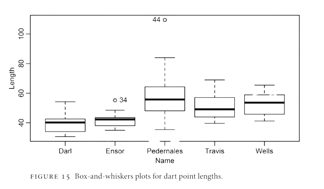

Boxplots from Carlson 2017

## Basic ggplot() syntax

```r
ggplot(data = <your data frame>, mapping = aes(x = <variable to be mapped to axis x>)) +
   geom_<geometry>()
```

1. Function `ggplot()` takes the data frame as an argument.
2. argument `aes()` serves to **map aesthetics** (axis x and y, colors etc.) to different variables from your data frame.
3. Functions with `geom_` prefix are **geometries**, ie. types of plots to draw. You can **set** specific arguments such as the color or shape here.
4. Note the `+` after each layer of the ggplot

Geoms for one variable:

- `geom_histogram()`
- `geom_density()`
- `geom_bar()`

## Plots for one variable

## Histogram

- **Distribution** of values of a **quantitative** variable.

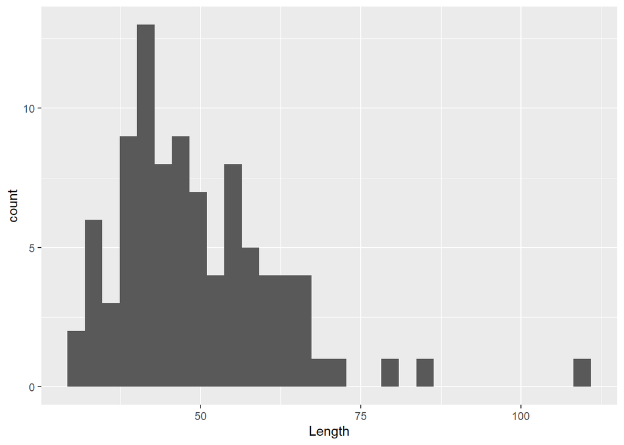

```r
ggplot(data = df_dartpoints, mapping =  aes(x = Length)) +
   geom_histogram()
```

## Histogram

- note that you don’t need to write arguments `data =` and `mapping =`

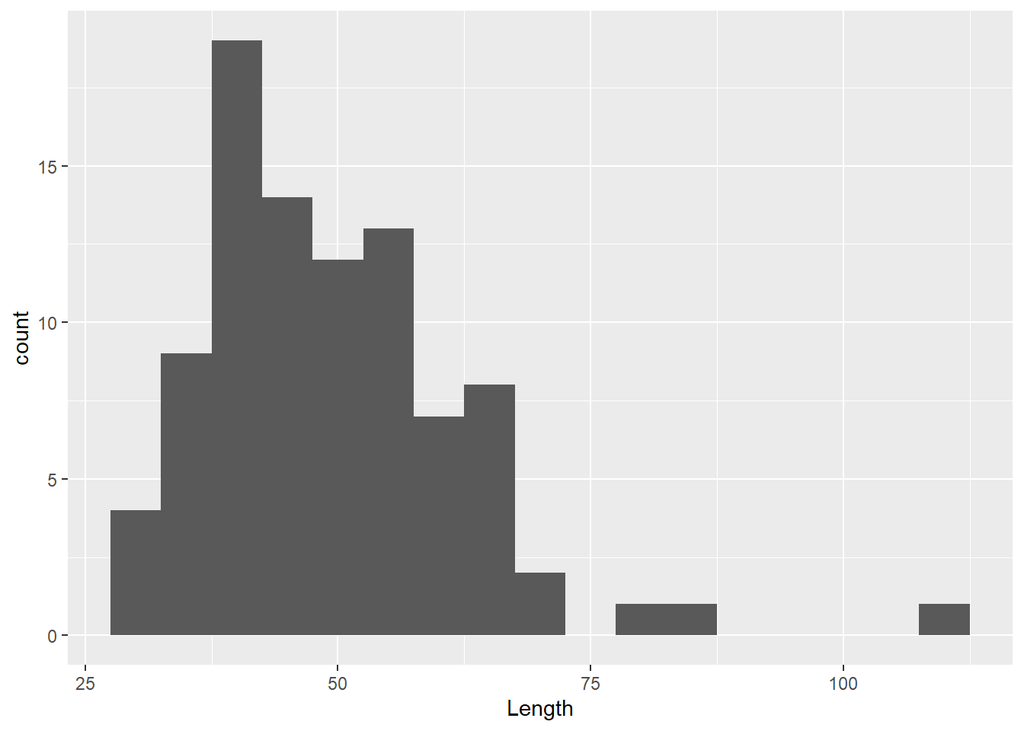

```r
ggplot(df_dartpoints, aes(x = Length)) +
  geom_histogram(binwidth = 5)
```

## Histogram

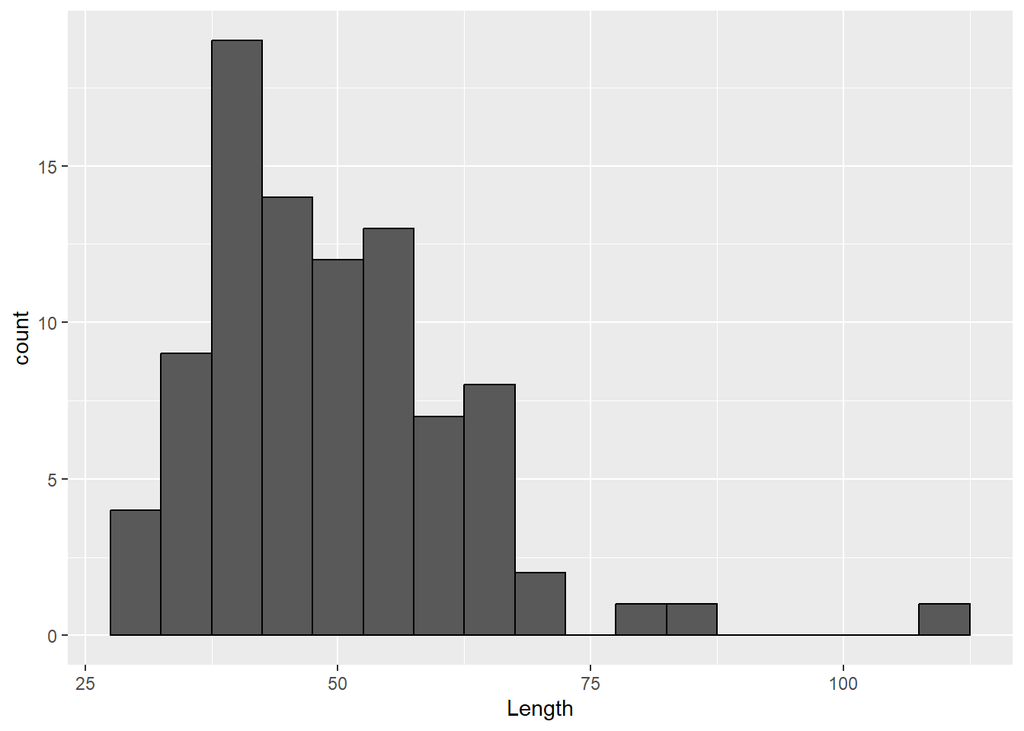

```r
ggplot(df_dartpoints, aes(x = Length))+
  geom_histogram(binwidth = 5, color = "black")
```

## Histogram

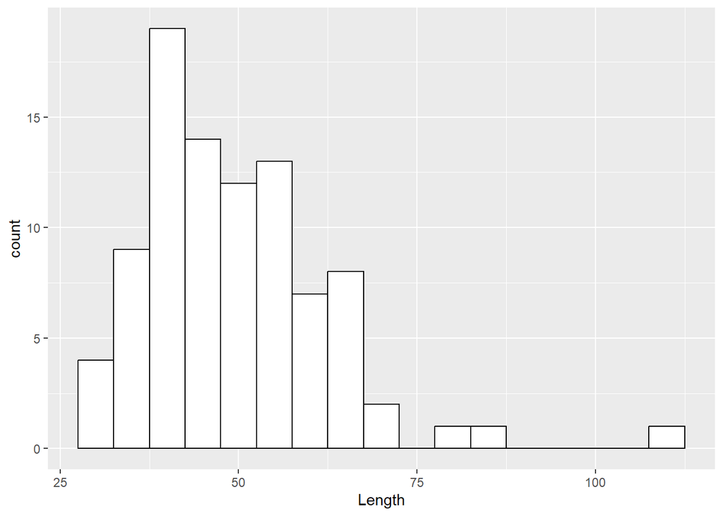

```r
ggplot(df_dartpoints, aes(x = Length)) +
  geom_histogram(binwidth = 5, color = "black", fill = "white")
```

## Labels

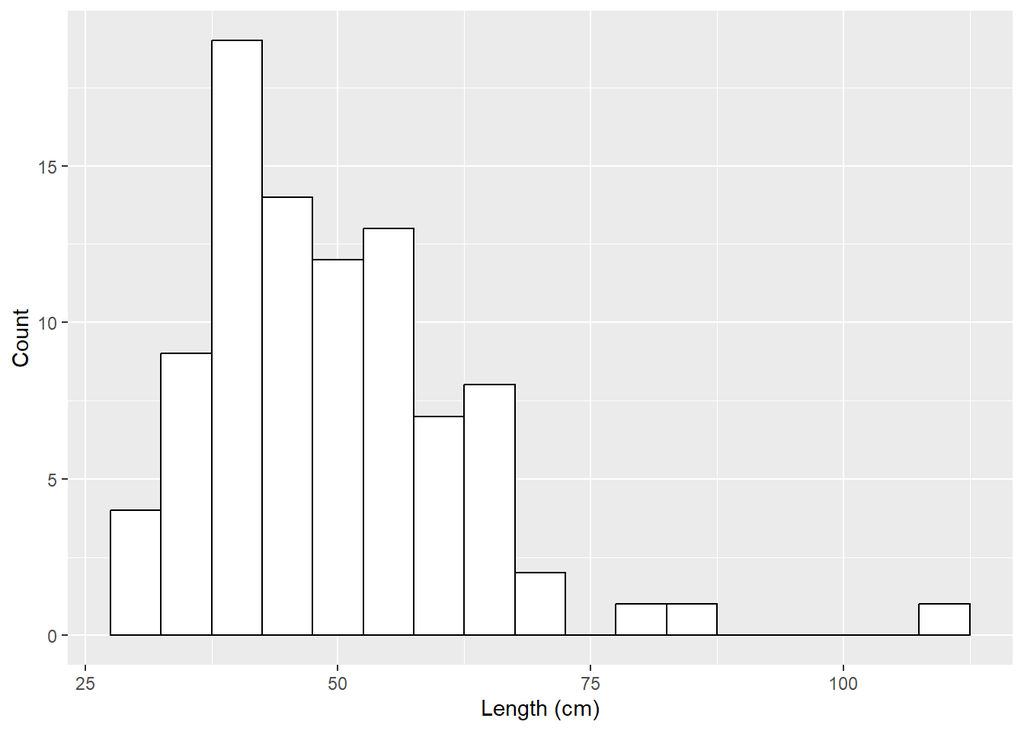

```r
ggplot(df_dartpoints, aes(x = Length)) +
  geom_histogram(binwidth = 5, color = "black", fill = "white") +
  labs(x = "Length (cm)", y = "Count")
```

## Labels

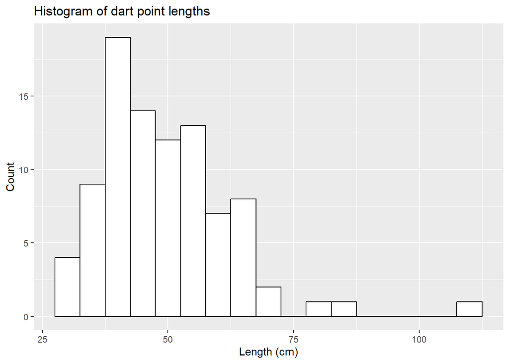

```r
ggplot(df_dartpoints, aes(x = Length)) +
  geom_histogram(binwidth = 5, color = "black", fill = "white") +
  labs(x = "Length (cm)", y = "Count",
       title = "Histogram of dart point lengths")
```

## Labels

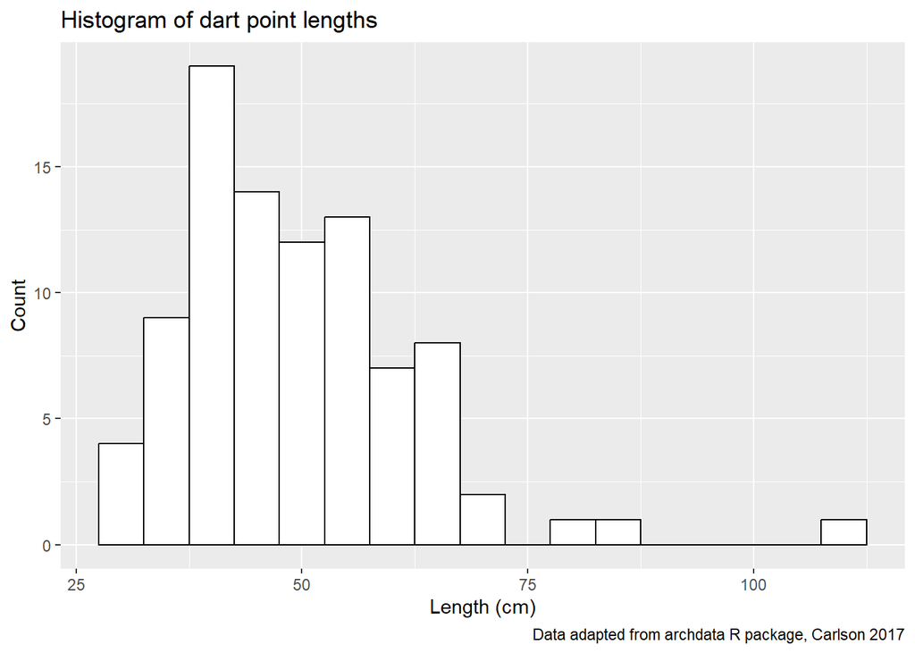

```r
ggplot(df_dartpoints, aes(x = Length))+
  geom_histogram(binwidth = 5, color = "black", fill = "white") +
  labs(x = "Length (cm)", y = "Count",
       title = "Histogram of dart point lengths",
       caption = "Data adapted from archdata R package, Carlson 2017")
```

## Density plot

- **Distribution** of values of a **quantitative** variable.

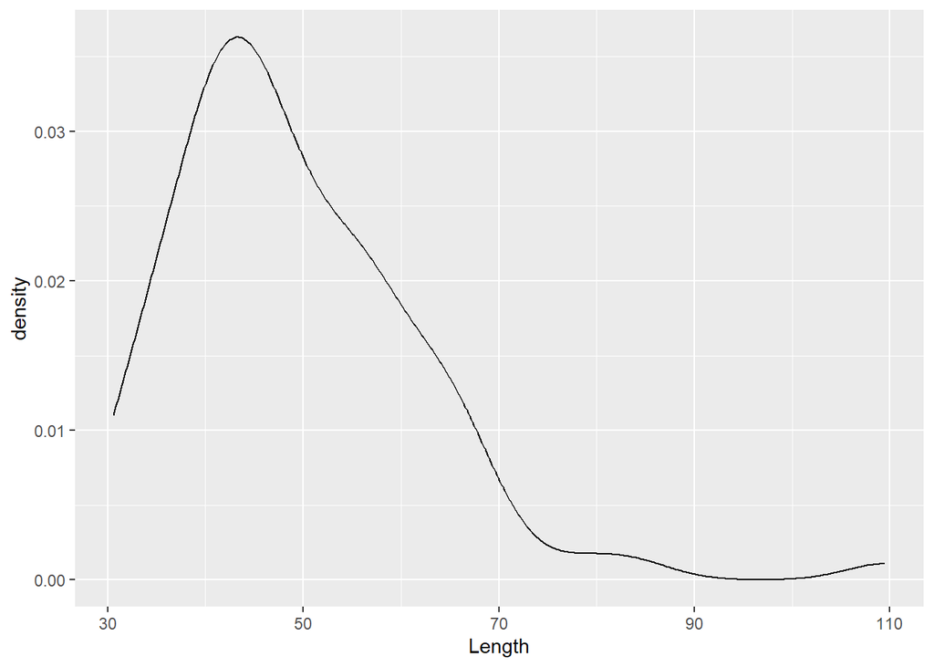

```r
ggplot(df_dartpoints, aes(x = Length)) +
  geom_density()
```

## Density plot - setting the color

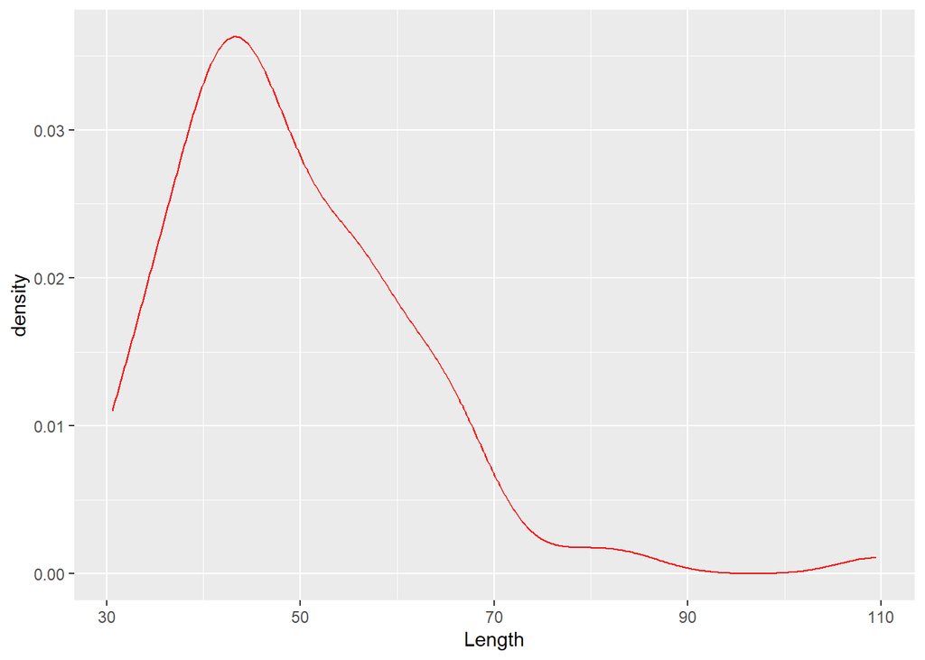

```r
ggplot(df_dartpoints, aes(x = Length)) +
  geom_density(color = "red")
```

## Density plot - mapping variables by color

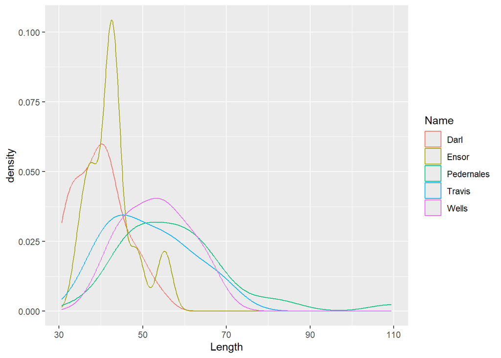

```r
ggplot(df_dartpoints, aes(x = Length, color = Name)) +
  geom_density()
```

## Density plot

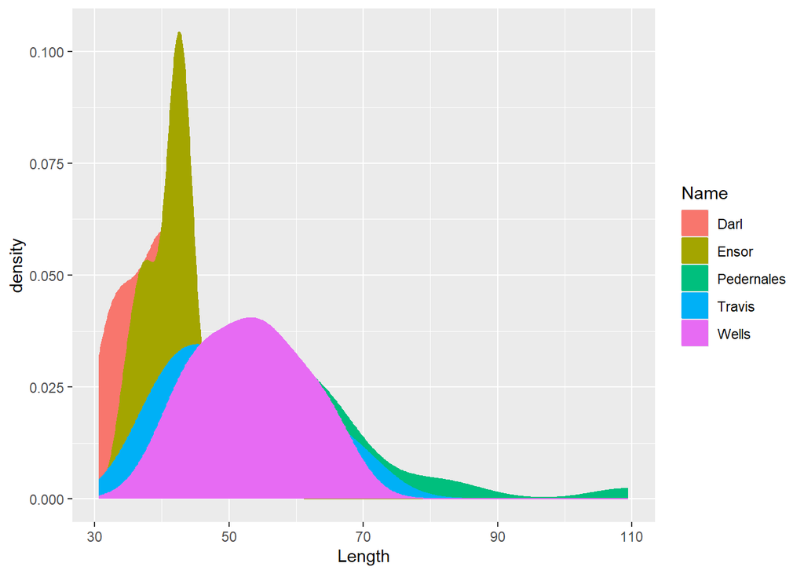

```r
ggplot(df_dartpoints, aes(x = Length, color = Name, fill = Name)) +
  geom_density()
```

## Density plot

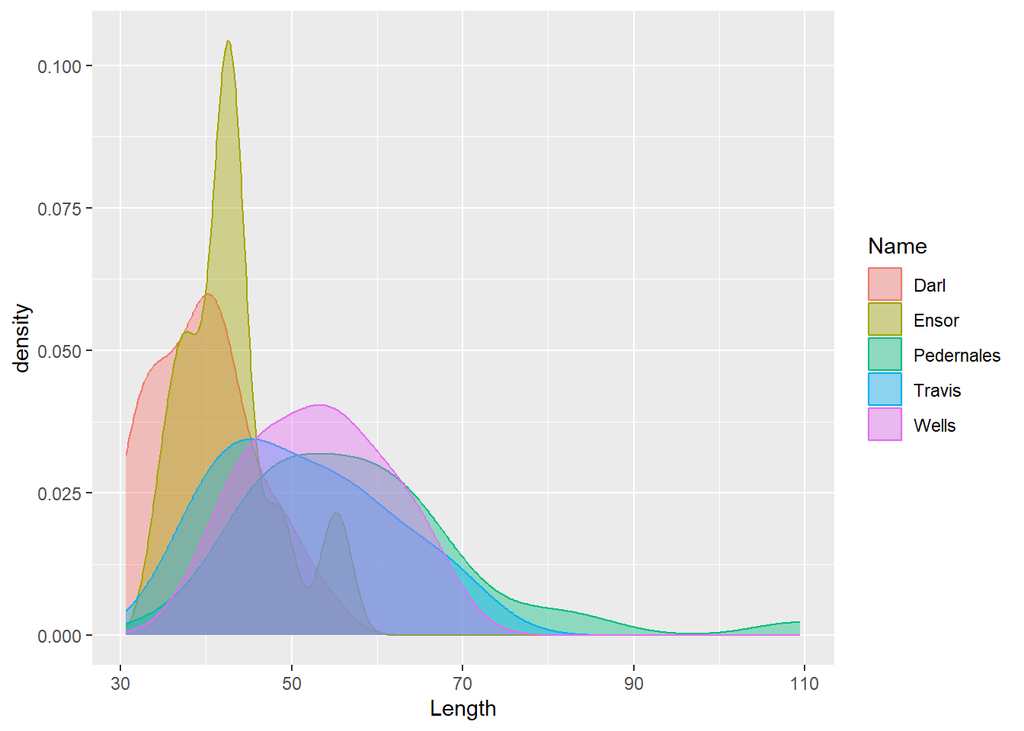

```r
ggplot(df_dartpoints, aes(x = Length, color = Name, fill = Name)) +
  geom_density(alpha = 0.4)
```

## Bar chart

- **Distribution** of values of a **qualitative** variable.

Distribution of types of dart points.

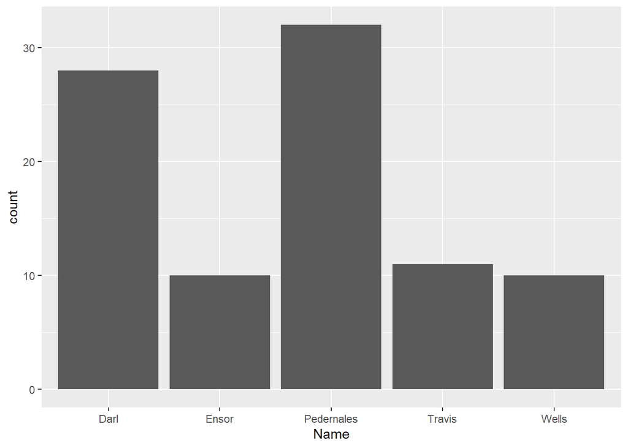

```r
ggplot(data = df_dartpoints, aes(x = Name)) +
  geom_bar()
```

## Bar chart

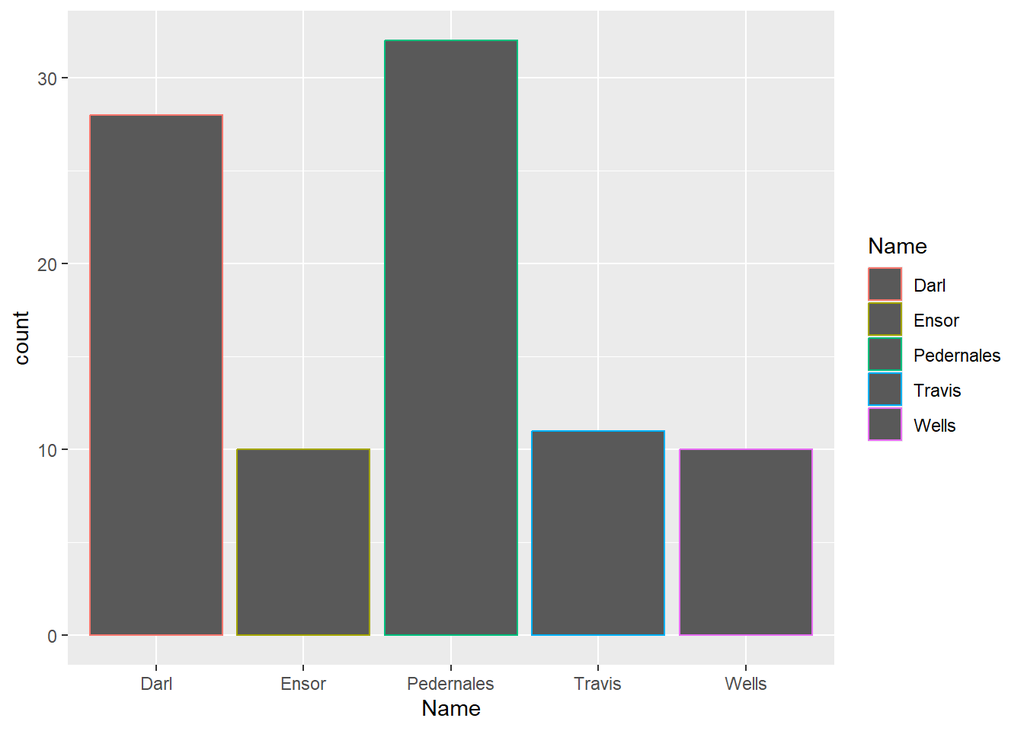

```r
ggplot(data = df_dartpoints, aes(x = Name, color = Name)) +
  geom_bar()
```

## Bar chart

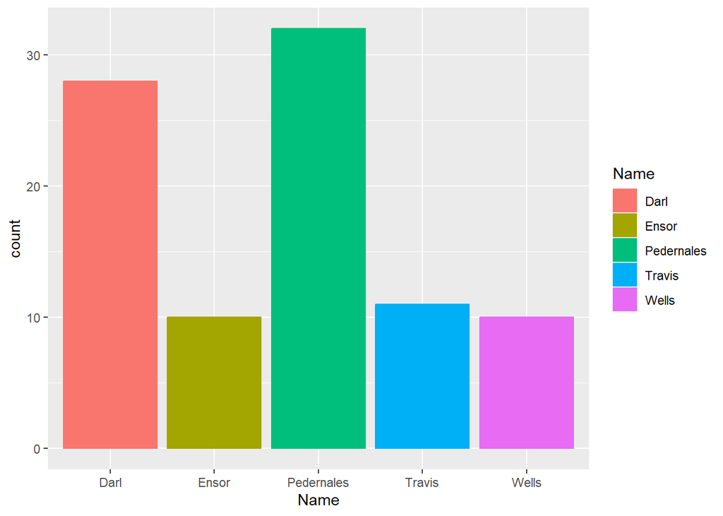

```r
ggplot(data = df_dartpoints, aes(x = Name, color = Name, fill = Name)) +
  geom_bar()
```

## Bar chart

- notice here the difference between **setting** color of our choice and **mapping** color based on one variable

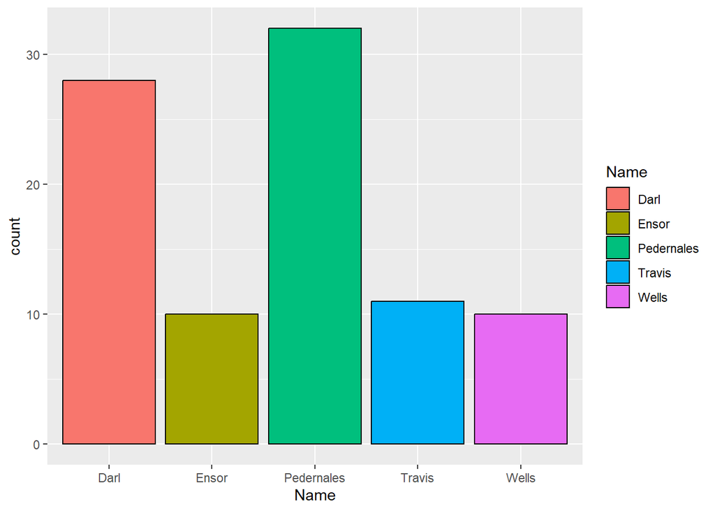

```r
ggplot(data = df_dartpoints, aes(x = Name, fill = Name)) +
  geom_bar(color = "black")
```

[AES_707](https://petrpajdla.github.io/stat4arch/) *Statistics seminar for archaeologists* | Data viz